# Generalized Log-Logistic Distributions

Samvel B. Gasparyan

https://gasparyan.co/

14 August, 2026

### Setup

[figure not shown]

Load the package `hce` and check the version

```r
library(hce)
packageVersion("hce")
```

```
#> [1] '0.9.4.6'
```

For citing the package, run `citation("hce")` (Gasparyan 2026).

## Background

In this vignette, we describe survival-analysis concepts relevant to hierarchical composite endpoints (HCEs). Many HCEs are constructed from multivariate, or dependent, survival endpoints. The generalized log-logistic (GLL) distribution is a flexible parametric model with an intuitive motivation for modelling clinical trial data. The GLL is also known as the Burr Type XII or Singh-Maddala distribution.

We first introduce the GLL distribution as the marginal distribution obtained when event times follow a Weibull model conditional on patient-level gamma frailty. We then describe properties of this distribution that are useful for simulating survival data in clinical trials and constructing HCEs.

The GLL distribution generalizes the log-logistic distribution (Bennett 1983b), which belongs to the family of survival proportional-odds models (SPOMs) (Bennett 1983a). SPOMs have been used in heart failure (HF) clinical trials to model time to the first event in the composite endpoint of HF hospitalization and cardiovascular death (CVD), an established primary endpoint in pivotal HF trials (Myte et al. 2025).

## Weibull distribution conditional on gamma frailty

Suppose that

$$\xi \sim \operatorname{Gamma}\left(\frac{1}{\theta},
\frac{1}{\theta}\right),$$

where the first parameter is the shape and the second is the rate. The random variable $\xi$ represents patient-level frailty, reflecting population heterogeneity in baseline event risk. For $\theta > 0$,

$$\mathrm{E}(\xi) = 1,
\qquad
\mathrm{Var}(\xi) = \theta.$$

Thus, larger values of $\theta$ indicate greater heterogeneity in the population.

Let $T$ denote the time to an event of interest. Conditional on the frailty term, assume that

$$T \mid \xi \sim \operatorname{Weibull}(\lambda \xi, \alpha),$$

where $\lambda > 0$ is the rate parameter and $\alpha > 0$ is the shape parameter. Under this rate-scale parameterization, the conditional survival and cumulative hazard functions are

$$S(t \mid \xi)
=
\exp\{-\Lambda(t \mid \xi)\}
=
\exp(-\lambda \xi t^\alpha),$$

and

$$\Lambda(t \mid \xi) = \lambda \xi t^\alpha.$$

Integrating over the gamma frailty distribution gives the marginal survival function

$$S(t) = \left\{1 + \theta \Lambda(t)\right\}^{-1/\theta},$$

where $\Lambda(t)$ is the cumulative baseline hazard. For the Weibull baseline, this becomes

$$S(t|\lambda,\alpha,\theta) = \left(1 + \theta \lambda
t^\alpha\right)^{-1/\theta}.$$

The parameters $\lambda$ and $\alpha$ are the Weibull rate and shape parameters, respectively, and must be positive. The heterogeneity parameter $\theta$ is non-negative. When $\theta = 0$, the expression is interpreted as a limit and reduces to the standard Weibull survival function without frailty:

$$S(t|\lambda,\alpha,\theta=0) = \exp(-\lambda t^\alpha).$$
The density function is given by:
$$f(t|\lambda,\alpha,\theta) = \lambda\alpha t^{\alpha-1}\left(1 + \theta
\lambda t^\alpha\right)^{-1/\theta-1},$$
and when $\theta = 0$, it reduces to the standard Weibull density function without frailty:

$$f(t|\lambda,\alpha,\theta=0) = \lambda\alpha t^{\alpha-1}\exp(-\lambda
t^\alpha).$$

- The GLL distribution is also known as the **Burr Type XII** or **Singh-Maddala** distribution.
- When $\theta = 1$, its marginal survival function corresponds to the log-logistic distribution, which is implemented, for example, in the `flexsurv` package (Jackson 2016).
- When $\alpha=1,$ the distribution reduces to the **Lomax**, or **Pareto Type II**, distribution. This is the marginal distribution obtained when an exponential random variable has a gamma-distributed frailty rate.

The following functions are available for simulating from the conditional Weibull model with gamma frailty and from the marginal GLL family. See `?GLL` for documentation:

```r
rweibullGF()
rGLL()
pGLL()
qGLL()
hGLL()
HGLL()
```

As usual, `r` denotes random-number generation, `p` the cumulative distribution function, `q` the quantile function, and `h` the hazard function. The capitalized `H` denotes the cumulative hazard function. The density function `dGLL()` also includes a `log` argument for calculating the log-density.

The `rGLL()` function uses the inverse-transformation method by applying the GLL quantile function to a standard uniform random variable. Similarly, `rweibullGF()` first samples the frailty term $\xi$ from its gamma distribution and then applies the inverse conditional Weibull survival function to a standard uniform random variable. These approaches generate samples from the same marginal distribution. The following code illustrates their equivalence empirically.

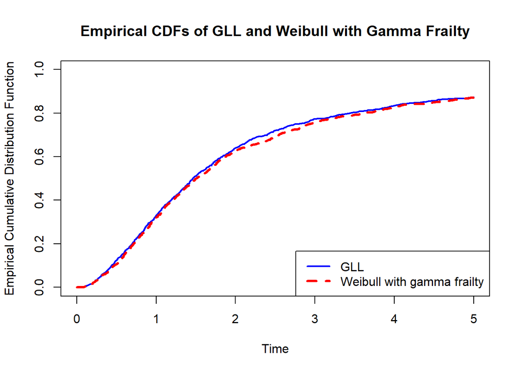

```r
n <- 1000
rate <- 0.5
shape <- 2
theta <- 1.5

y_gll <- rGLL(
  n,
  rate = rate,
  shape = shape,
  theta = theta
)

y_weibull_gf <- rweibullGF(
  n,
  rate = rate,
  shape = shape,
  theta = theta
)

ecdf_gll <- ecdf(y_gll)
ecdf_weibull_gf <- ecdf(y_weibull_gf)

x <- seq(0, 5, 0.01)

plot(
  x,
  ecdf_gll(x),
  type = "s",
  col = "blue",
  lwd = 2,
  lty = 1,
  ylim = c(0, 1),
  ylab = "Empirical Cumulative Distribution Function",
  xlab = "Time",
  main = "Empirical CDFs of GLL and Weibull with Gamma Frailty"
)

lines(
  x,
  ecdf_weibull_gf(x),
  type = "s",
  col = "red",
  lwd = 3,
  lty = 2
)

legend(
  "bottomright",
  legend = c("GLL", "Weibull with gamma frailty"),
  col = c("blue", "red"),
  lwd = c(2, 3),
  lty = c(1, 2)
)
```

## Time-dependent hazard ratio

The marginal hazard function of the GLL distribution is

$$h(t \mid \lambda, \alpha, \theta)
=
\frac{\lambda \alpha t^{\alpha - 1}}
{1 + \theta \lambda t^\alpha}.$$

Consider two independent GLL random variables with the same shape parameter $\alpha$ and heterogeneity parameter $\theta$, but with different rate parameters $\lambda_1$ and $\lambda_0$. Their marginal hazard ratio is

$$HR(t)
=
\frac{\lambda_1}{\lambda_0}
\frac{1 + \theta \lambda_0 t^\alpha}
{1 + \theta \lambda_1 t^\alpha}.$$

Thus, unlike the conditional Weibull hazard ratio, the marginal hazard ratio is generally time-dependent when $\theta > 0$. As time increases, the hazard ratio tends toward one when $\lambda_1 \ne \lambda_0$, reflecting the attenuation of treatment contrasts caused by unobserved heterogeneity.

The following code illustrates the hazard ratio for different values of the heterogeneity parameter, using $\alpha = 0.85$.

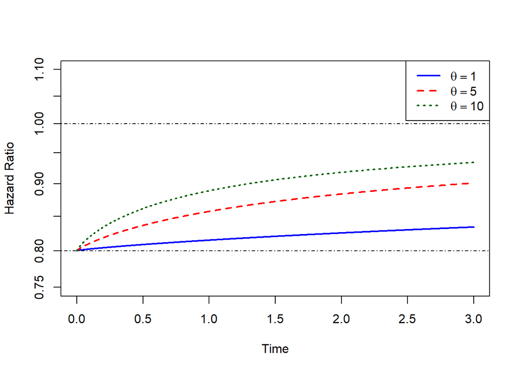

```r
rate1 <- 0.08
rate0 <- 0.10
shape <- 0.85

hr_at_time_zero <- rate1 / rate0

hazard_ratio <- function(time, theta, alpha = shape) {
  hr_at_time_zero *
    (1 + theta * rate0 * time^alpha) /
    (1 + theta * rate1 * time^alpha)
}

time <- seq(0, 3, 0.001)

plot(
  time,
  hazard_ratio(time, theta = 1),
  type = "l",
  col = "blue",
  lwd = 2,
  ylim = c(0.75, 1.1),
  log = "y",
  ylab = "Hazard Ratio",
  xlab = "Time",
  lty = 1
)

lines(
  time,
  hazard_ratio(time, theta = 5),
  col = "red",
  lwd = 2,
  lty = 2
)

lines(
  time,
  hazard_ratio(time, theta = 10),
  col = "darkgreen",
  lwd = 2,
  lty = 3
)

abline(
  h = c(hr_at_time_zero, 1),
  lty = 4
)

legend(
  "topright",
  legend = expression(theta == 1, theta == 5, theta == 10),
  col = c("blue", "red", "darkgreen"),
  lwd = 2,
  lty = 1:3
)
```

## Time-dependent survival odds ratio

The marginal survival odds of the GLL distribution can be calculate as

$$SO(t)=\frac{S(t)}{1-S(t)}=\frac{1}{(1+\theta\lambda
t^\alpha)^\frac{1}{\theta}-1},$$
therefore, the survival odds ratio of the active vs control with the same $\theta$ and $\alpha$ but different rate parameters ($\lambda_0$ for control and $\lambda_1$ for active) is given by
$$SOR(t)=\frac{(1+\theta\lambda_0
t^\alpha)^\frac{1}{\theta}-1}{(1+\theta\lambda_1
t^\alpha)^\frac{1}{\theta}-1}.$$
If we consider $1/SOR(t),$ then for $\theta=1$ which corresponds to the log-logistic distribution, $1/SOR(t)=\frac{\lambda_1}{\lambda_0}$ confirming the proportionality of odds for log-logistic distributions with the same shape parameter. In general, $1/SOR(t)$ is time dependent and $1/SOR(0)=\frac{\lambda_1}{\lambda_0}$ and when $t\to\infty,$
$$1/SOR(t)\to
\left(\frac{\lambda_1}{\lambda_0}\right)^\frac{1}{\theta}.$$

## Time-invariant quantile ratio

The GLL quantile function $Q(p)$ is given by

$$Q(p \mid \lambda,\alpha,\theta)
=
\left[
\frac{(1-p)^{-\theta}-1}
{\theta\lambda}
\right]^{1/\alpha},
\qquad \theta>0.$$

When $\theta=0$, the GLL distribution reduces to the Weibull distribution. Taking the limit as $\theta\to0$ gives

$$Q(p \mid \lambda,\alpha,\theta=0)
=
\left[
\frac{-\log(1-p)}
{\lambda}
\right]^{1/\alpha}.$$

The quantile ratio for the active treatment relative to control is therefore

$$QR(p)
=
\frac{Q_1(p)}{Q_0(p)}
=
\left(\frac{\lambda_0}{\lambda_1}\right)^{1/\alpha}.$$

Thus, the quantile ratio is independent of $\theta$ and is the same for every quantile level.

The same result holds for $\theta=0$, because

$$\frac{Q_1(p)}{Q_0(p)}
=
\frac{
\left[-\log(1-p)/\lambda_1\right]^{1/\alpha}
}{
\left[-\log(1-p)/\lambda_0\right]^{1/\alpha}
}
=
\left(\frac{\lambda_0}{\lambda_1}\right)^{1/\alpha}.$$
Therefore, for the GLL distribution, the marginal hazard ratio is generally time-dependent. The marginal survival odds ratio is also time-dependent, except when $\theta=1$, which corresponds to the log-logistic distribution. In that special case, the survival odds ratio is time-invariant.

In contrast, when the two treatment groups have the same heterogeneity parameter $\theta$ and the same shape parameter $\alpha$, their quantile ratio is time-invariant for all $\theta \geq 0.$

Thus, the quantile ratio does not depend on the magnitude of the shared population heterogeneity parameter $\theta$. It can therefore provide a treatment-effect measure that is invariant to the level of population heterogeneity, provided that the assumption of a common $\theta$ and $\alpha$ is appropriate.

Under the GLL model, a median survival time can be estimated parametrically even when fewer than 50% of patients have experienced the event. However, this estimate depends on the validity of the GLL model. In contrast, a nonparametric estimate of the median requires the estimated survival curve to fall to or below $0.50$, which generally requires that at least 50% of patients experience the event.

## References

Bennett, Steve. 1983a. “Analysis of Survival Data by the Proportional Odds Model.” *Statistics in Medicine* 2 (2): 273–77. https://doi.org/10.1002/sim.4780020223.

———. 1983b. “Log-Logistic Regression Models for Survival Data.” *Journal of the Royal Statistical Society Series C: Applied Statistics* 32 (2): 165–71. https://doi.org/10.2307/2347295.

Jackson, Christopher. 2016. “flexsurv: A Platform for Parametric Survival Modeling in R.” *Journal of Statistical Software* 70 (8): 1–33. https://doi.org/10.18637/jss.v070.i08.

Myte, Robin, Andrea Mattsson, Matt Poole, Dustin J. Little, Per Nyström, Alasdair Henderson, Brian L. Claggett, Samvel B. Gasparyan, Scott D. Solomon, and John J. V. McMurray. 2025. “Survival Odds to Minimize Risk Heterogeneity Bias in Heart Failure Trials: Application to Dapagliflozin.” *Circulation: Heart Failure* 18 (12): e013496. https://doi.org/10.1161/circheartfailure.125.013496.